# DATA 607 Project 3

Puja Roy, Chhiring Lama, William Berritt

2024-03-17

### Load the packages

```r
library(tidyverse)
library(openintro)

library('DBI')
library('RMySQL')
```

### Introduction

For this project, the aim is to obtain data to answer the question, “Which are the most valued data science skills?”

We obtained the Data Science Job Salaries dataset from Kaggle: https://www.kaggle.com/datasets/ruchi798/data-science-job-salaries?resource=download which contains information about salaries of jobs in the Data Science domain. The dataset includes work year, company size, job title, salary in USD, employee residence and company location.

We decided to focus on job titles that included salary in the USD and worked with variables including the work year, company size and company location.

### Load the data

We stored the data in MySQL workbench and azure database, joined the tables that contained data of company and job and then queried it using R.

```r
# List tables in the database (not shown in the published document)
dbListTables(mydb)
```

```
## [1] "chess_tournament"  "clean_company_ids" "clean_job_dets"
## [4] "company"           "job"               "movie_ratings"
```

```r
# Retrieve data from a specific table
df1 <- dbGetQuery(mydb,'select * from company')

# Print the retrieved data
print(df1)
```

```
##     company_id employee_residence remote_ratio company_location company_size
## 1            1                 DE            0               DE            L
## 2            2                 JP            0               JP            S
## 3            3                 GB           50               GB            M
## 4            4                 HN            0               HN            S
## 5            5                 US           50               US            L
## 6            6                 US          100               US            L
## 7            7                 US          100               US            S
## 8            8                 HU           50               HU            L
## 9            9                 NZ           50               NZ            S
## 10          10                 FR            0               FR            S
## 11          11                 IN            0               IN            L
## 12          12                 FR            0               FR            M
## 13          13                 PK           50               PK            L
## 14          14                 JP          100               JP            S
```

[output cut: 309 more lines]

### Join the Tables to obtain the full data

```r
job <- dbGetQuery(mydb,'select * from job')

company <- dbGetQuery(mydb,'select * from company')

total_df <- left_join(company, job, by='cid')
print(total_df)
```

```
##     company_id employee_residence remote_ratio company_location company_size
## 1            1                 DE            0               DE            L
## 2            1                 DE            0               DE            L
## 3            1                 DE            0               DE            L
## 4            2                 JP            0               JP            S
## 5            2                 JP            0               JP            S
## 6            3                 GB           50               GB            M
## 7            4                 HN            0               HN            S
## 8            5                 US           50               US            L
## 9            5                 US           50               US            L
## 10           5                 US           50               US            L
## 11           5                 US           50               US            L
## 12           5                 US           50               US            L
## 13           5                 US           50               US            L
## 14           5                 US           50               US            L
```

[output cut: 2249 more lines]

### Data Exploration and Analysis

We checked for missing and duplicate values. As shown below in the results, there were no missing or duplicate values.

```r
# Data Exploration
str(total_df)
```

```
## 'data.frame':    565 obs. of  14 variables:
##  $ company_id        : int  1 1 1 2 2 3 4 5 5 5 ...
##  $ employee_residence: chr  "DE" "DE" "DE" "JP" ...
##  $ remote_ratio      : int  0 0 0 0 0 50 0 50 50 50 ...
##  $ company_location  : chr  "DE" "DE" "DE" "JP" ...
##  $ company_size      : chr  "L" "L" "L" "S" ...
##  $ cid               : chr  "DE_0_DE_L" "DE_0_DE_L" "DE_0_DE_L" "JP_0_JP_S" ...
##  $ job_title_id      : int  1 258 271 2 151 3 4 5 38 59 ...
##  $ work_year         : int  2020 2021 2021 2020 2021 2020 2020 2020 2020 2020 ...
##  $ experience_level  : chr  "MI" "EX" "EN" "SE" ...
##  $ employment_type   : chr  "FT" "FT" "FT" "FT" ...
##  $ job_title         : chr  "Data Scientist" "Director of Data Science" "Data Science Consultant" "Machine Learning Scientist" ...
##  $ salary            : int  70000 120000 65000 260000 168000 85000 20000 150000 250000 120000 ...
##  $ salary_currency   : chr  "EUR" "EUR" "EUR" "USD" ...
##  $ salary_in_usd     : int  79833 141846 76833 260000 168000 109024 20000 150000 250000 120000 ...
```

```r
summary(total_df)
```

```
##    company_id     employee_residence  remote_ratio    company_location
##  Min.   :  1.00   Length:565         Min.   :  0.00   Length:565
##  1st Qu.: 21.00   Class :character   1st Qu.: 50.00   Class :character
##  Median : 42.00   Mode  :character   Median :100.00   Mode  :character
##  Mean   : 52.98                      Mean   : 69.91
##  3rd Qu.: 71.00                      3rd Qu.:100.00
##  Max.   :161.00                      Max.   :100.00
##  company_size           cid             job_title_id   work_year
##  Length:565         Length:565         Min.   :  1   Min.   :2020
##  Class :character   Class :character   1st Qu.:142   1st Qu.:2021
##  Mode  :character   Mode  :character   Median :283   Median :2021
##                                        Mean   :283   Mean   :2021
##                                        3rd Qu.:424   3rd Qu.:2022
##                                        Max.   :565   Max.   :2022
##  experience_level   employment_type     job_title             salary
##  Length:565         Length:565         Length:565         Min.   :    4000
##  Class :character   Class :character   Class :character   1st Qu.:   67000
##  Mode  :character   Mode  :character   Mode  :character   Median :  110925
##                                                           Mean   :  338116
##                                                           3rd Qu.:  165000
##                                                           Max.   :30400000
##  salary_currency    salary_in_usd
##  Length:565         Min.   :  2859
##  Class :character   1st Qu.: 60757
##  Mode  :character   Median :100000
##                     Mean   :110610
##                     3rd Qu.:150000
##                     Max.   :600000
```

```r
# Check for missing values
sum(is.na(total_df))
```

```
## [1] 0
```

```r
# Print out the column names
print(colnames(total_df))
```

```
##  [1] "company_id"         "employee_residence" "remote_ratio"
##  [4] "company_location"   "company_size"       "cid"
##  [7] "job_title_id"       "work_year"          "experience_level"
## [10] "employment_type"    "job_title"          "salary"
## [13] "salary_currency"    "salary_in_usd"
```

To verify duplicate values in the dataset, I used the duplicated() function. This creates a new dataframe displaying any duplication values. I also used the sum function.

```r
num_duplicates <- sum(duplicated(total_df))
# Check for duplicates
duplicates <- total_df[duplicated(total_df), ]
print(duplicates)
```

```
##  [1] company_id         employee_residence remote_ratio       company_location
##  [5] company_size       cid                job_title_id       work_year
##  [9] experience_level   employment_type    job_title          salary
## [13] salary_currency    salary_in_usd
## <0 rows> (or 0-length row.names)
```

There are no duplicate values in the dataset.

### Extract Relevant Skills

I extracted certain skills based on job titles including Data Scientist, Data Analyst and Machine Learning Engineer which would imply skills relevant to data science.

```r
# Analysis
# Extract relevant skills (based on job titles)
data_science_roles <- c("Data Scientist", "Data Analyst", "Machine Learning Engineer")
data_science_data <- total_df[total_df$job_title %in% data_science_roles, ]
print(data_science_data)
```

```
##     company_id employee_residence remote_ratio company_location company_size
## 1            1                 DE            0               DE            L
## 8            5                 US           50               US            L
## 9            5                 US           50               US            L
## 10           5                 US           50               US            L
## 12           5                 US           50               US            L
## 13           5                 US           50               US            L
## 14           5                 US           50               US            L
## 15           5                 US           50               US            L
## 16           5                 US           50               US            L
## 17           5                 US           50               US            L
## 21           6                 US          100               US            L
## 24           6                 US          100               US            L
## 31           6                 US          100               US            L
## 32           6                 US          100               US            L
```

[output cut: 741 more lines]

I used the dplyr library to filter the data and compute the summary statistics including the median, mean, min and max salary by job title. The Data Scientist job title had the highest mean salary among the other job titles based on data science roles.

```r
library(dplyr)

# Filter data for relevant job titles
data_science_roles <- c("Data Scientist", "Data Analyst", "Machine Learning Engineer")
data_science_data <- total_df[total_df$job_title %in% data_science_roles, ]

# Summary statistics of salary by job title
summary_stats <- data_science_data %>%
  group_by(job_title) %>%
  summarise(
    median_salary = median(salary_in_usd),
    mean_salary = mean(salary_in_usd),
    min_salary = min(salary_in_usd),
    max_salary = max(salary_in_usd)
  )

print(summary_stats)
```

```
## # A tibble: 3 × 5
##   job_title                 median_salary mean_salary min_salary max_salary
##   <chr>                             <dbl>       <dbl>      <int>      <int>
## 1 Data Analyst                      90000      90090.       6072     200000
## 2 Data Scientist                   100000     103336.       2859     412000
## 3 Machine Learning Engineer         87425     101165.      20000     250000
```

### Salary Distributions based on Job Title, Work Experience & Location

We created visualizations to display the summary statistics of salary by job title using ggplot2. Below is a boxplot where each box represents the distribution of salaries for each job title. It provides a visual comparison of the median, quartiles, and potential outliers for each job title’s salary distribution.

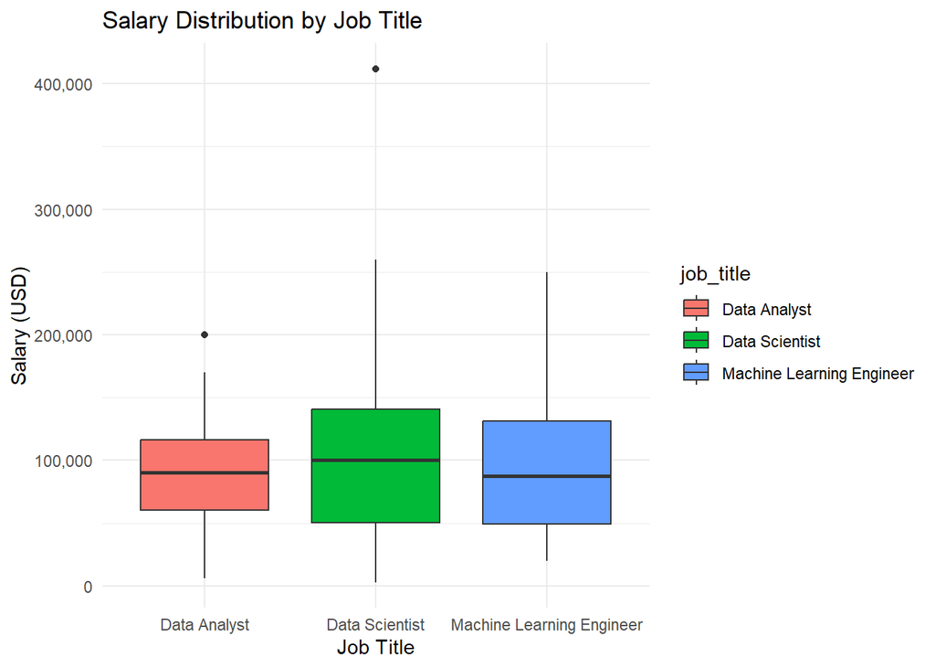

```r
# Boxplot visualization with color and removed scientific notation
boxplot <- ggplot(data_science_data, aes(x = job_title, y = salary_in_usd, fill = job_title)) +
  geom_boxplot() +
  scale_y_continuous(labels = scales::comma) +  # Remove scientific notation
  labs(title = "Salary Distribution by Job Title",
       x = "Job Title",
       y = "Salary (USD)") +
  theme_minimal()

print(boxplot)
```

We directly searched for the highest salary across all job titles in the data_science_data data frame by using the which.max() function. The job title “Data Scientist” had the highest salary: $412,000 for the work year 2020 and experience level SE. The job title “Data Scientist” had the lowest salary: $2859 for the work year 2021 and experience level MI.

```r
# Find the row index of the highest salary
highest_salary_index <- which.max(data_science_data$salary_in_usd)

# Get the corresponding row with the highest salary
highest_salary_row <- data_science_data[highest_salary_index, ]

print(highest_salary_row)
```

```
##    company_id employee_residence remote_ratio company_location company_size
## 34          6                 US          100               US            L
##            cid job_title_id work_year experience_level employment_type
## 34 US_100_US_L           64      2020               SE              FT
##         job_title salary salary_currency salary_in_usd
## 34 Data Scientist 412000             USD        412000
```

```r
# Find the row index of the lowest salary
lowest_salary_index <- which.min(data_science_data$salary_in_usd)

# Get the corresponding row with the lowest salary
lowest_salary_row <- data_science_data[lowest_salary_index, ]

print(lowest_salary_row)
```

```
##     company_id employee_residence remote_ratio company_location company_size
## 166         24                 MX            0               MX            S
##           cid job_title_id work_year experience_level employment_type
## 166 MX_0_MX_S          177      2021               MI              FT
##          job_title salary salary_currency salary_in_usd
## 166 Data Scientist  58000             MXN          2859
```

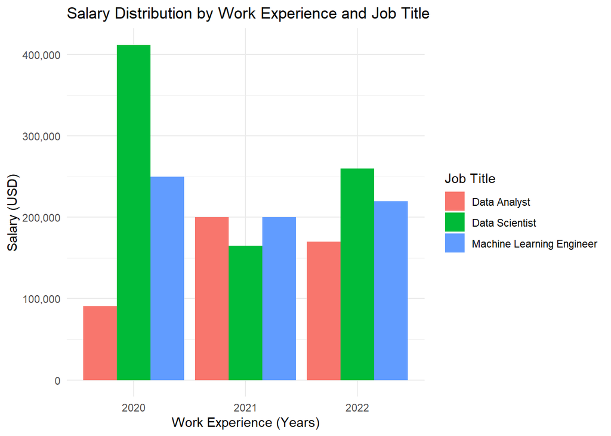

```r
# Create a bar plot for each job title
ggplot(data_science_data, aes(x = factor(work_year), y = salary_in_usd, fill = job_title)) +
  geom_bar(stat = "identity", position = "dodge") +
  labs(title = "Salary Distribution by Work Experience and Job Title",
       x = "Work Experience (Years)",
       y = "Salary (USD)",
       fill = "Job Title") +
  scale_y_continuous(labels = scales::comma_format()) +
  theme_minimal()
```

The bar plots below displays that there were a higher frequency of Data Scientist roles.

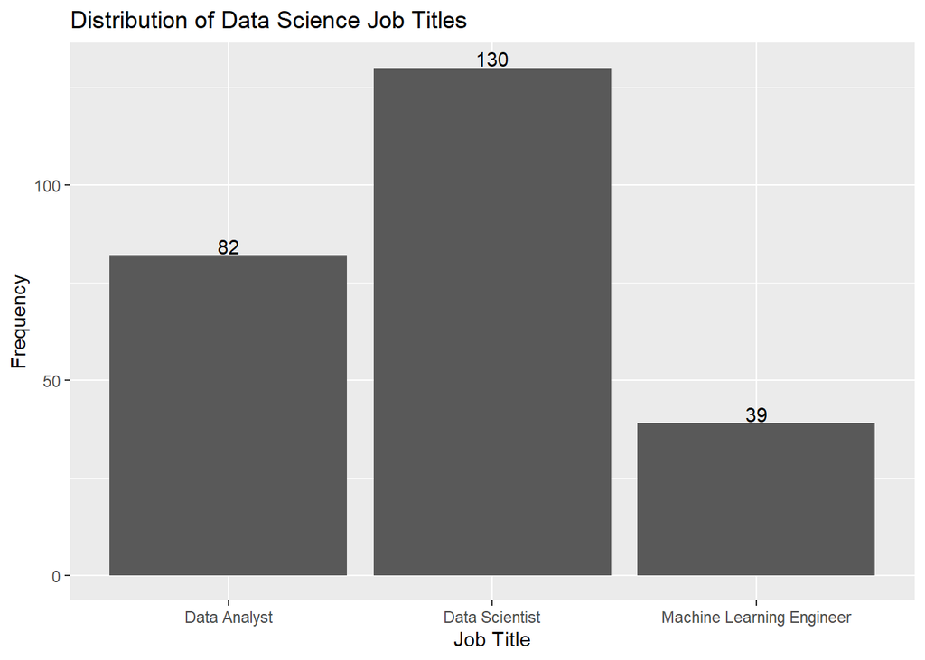

```r
# Create a bar plot of job titles with count values
ggplot(data_science_data, aes(x = job_title)) +
  geom_bar() +
  geom_text(stat = 'count', aes(label=..count..), vjust = -0.1) + # Add count values on top of bars
  labs(title = "Distribution of Data Science Job Titles",
       x = "Job Title",
       y = "Frequency") +
  theme(axis.text.x = element_text())
```

More scatter plots in the US and fewer in other locations suggest differences in the distribution and representation of salary data across different geographic regions, potentially reflecting underlying socioeconomic and industrial factors.

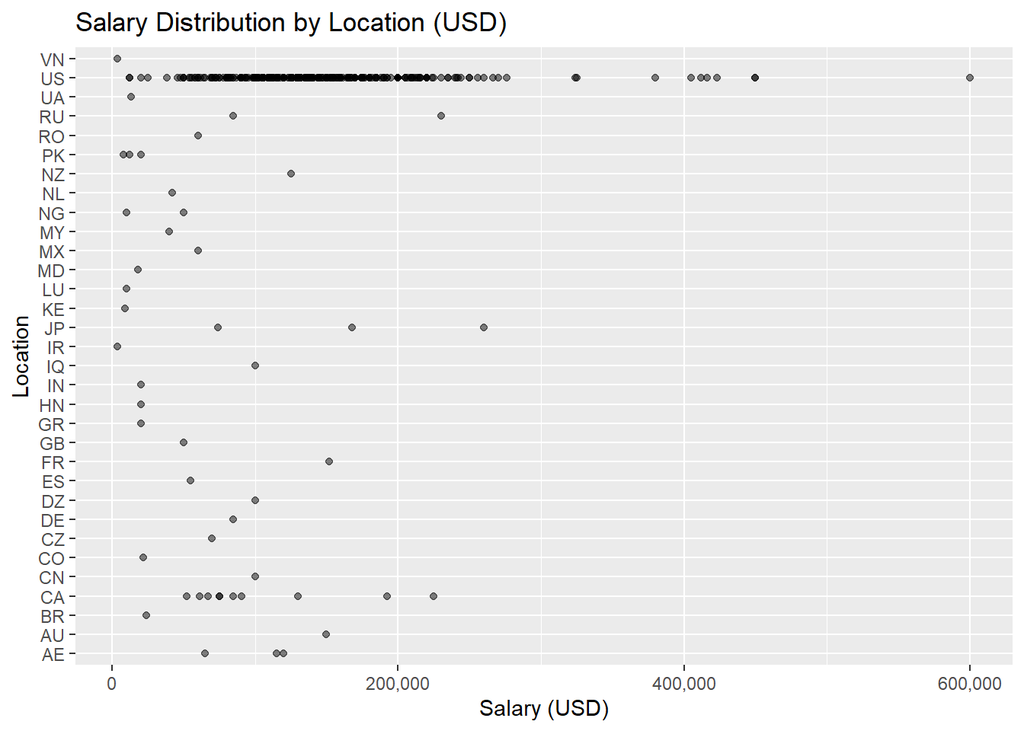

```r
# Filter data for USD locations
df_usd <- total_df[total_df$salary_currency == "USD", ]

# Scatter plot: Salary (USD) vs. Location (with reversed axes)
ggplot(df_usd, aes(x = salary_in_usd, y = company_location)) +
  geom_point(alpha = 0.5) +
  labs(title = "Salary Distribution by Location (USD)",
       x = "Salary (USD)",
       y = "Location") +
  scale_x_continuous(labels = scales::comma) +  # Remove scientific notation
  theme(axis.text.y = element_text(hjust = 1))  # Adjust text alignment
```

Based on this scatter plot displaying the salary distribution by Job title, there are a crowd of scattered points for the data science roles: Data Analyst, Data Scientist and Data Engineer. This means that there is a higher representation of these job titles being prevalent in the dataset compared to other data science job titles. It also seems that these 3 roles are popular in the data science industry.

The spread of these points for each job title category reflects significant differences in compensation depending on factors such as experience, education, location, and specific industry.

The clustering of points around these job titles could also indicate higher demand or competition in the job market for roles like Data Analyst, Data Scientist, and Data Engineer. Companies may be offering a wide range of salaries to attract talent in these fields.

To add on, this might also signify ongoing trends or changes in the industry where roles related to data analysis and data science are in high demand. This could be due to advancements in technology, the increasing importance of data-driven decision-making, or emerging sectors such as artificial intelligence and machine learning.

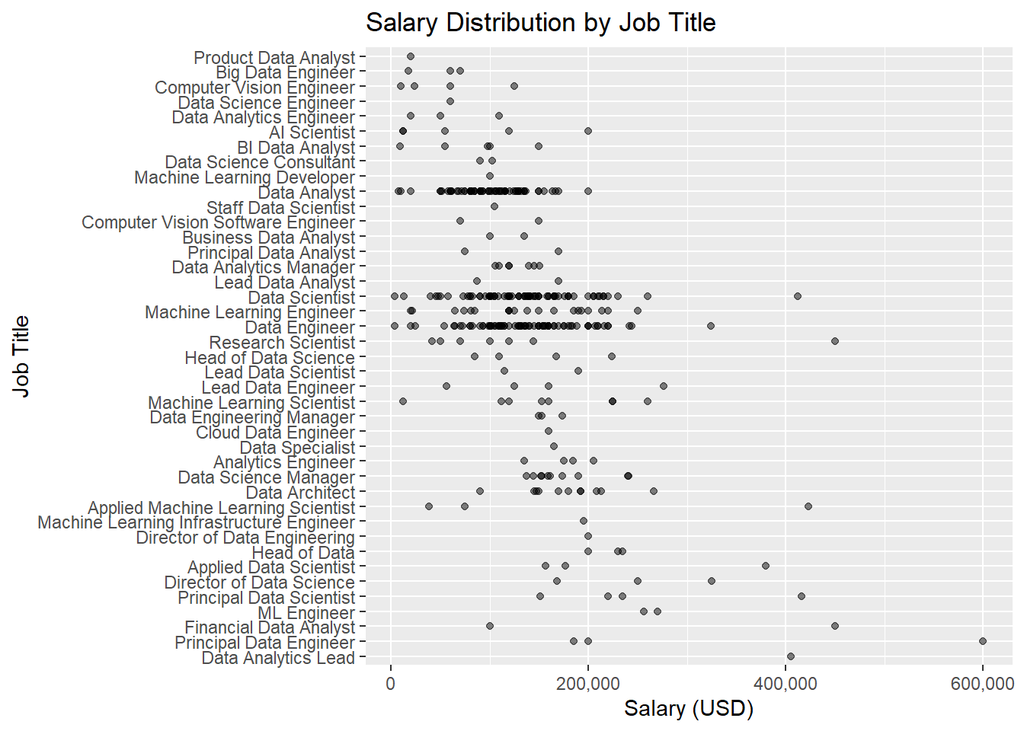

```r
# Filter data for USD locations
df_usd <- total_df[total_df$salary_currency == "USD", ]

# Scatter plot: Salary (USD) vs. Job Title (with reversed axes)
ggplot(df_usd, aes(x = salary_in_usd, y = reorder(job_title, desc(salary_in_usd)))) +
  geom_point(alpha = 0.5) +
  labs(title = "Salary Distribution by Job Title",
       x = "Salary (USD)",
       y = "Job Title") +
  scale_x_continuous(labels = scales::comma_format())  # Remove scientific notation
```

We also calculated the average salary by the work year, experience level, job title and company size and visualized the results in a heat map to observe the color intensity between each variable.

Each cell in the heatmap represents the average salary for a combination of the work year, job title, experience level, and company size.

The color intensity of each cell represents the average salary, with higher intensities indicating higher average salaries.

### Heat Maps based on Average Salary & Job Title by Work year, Experience Level, Employment Type & Company Size

```r
library(ggplot2)

# Calculate average salary by work year and job title
average_salary <- aggregate(salary_in_usd ~ work_year + job_title, data = df_usd, FUN = mean)
print(average_salary)
```

```
##    work_year                                job_title salary_in_usd
## 1       2021                             AI Scientist      26333.33
## 2       2022                             AI Scientist     160000.00
## 3       2022                       Analytics Engineer     175000.00
## 4       2022                   Applied Data Scientist     238000.00
## 5       2021       Applied Machine Learning Scientist     230700.00
## 6       2022       Applied Machine Learning Scientist      75000.00
## 7       2020                          BI Data Analyst      98000.00
## 8       2021                          BI Data Analyst      78568.00
## 9       2020                        Big Data Engineer      70000.00
## 10      2021                        Big Data Engineer      39000.00
## 11      2020                    Business Data Analyst     117500.00
## 12      2021                      Cloud Data Engineer     160000.00
## 13      2020                 Computer Vision Engineer      60000.00
## 14      2021                 Computer Vision Engineer      24000.00
```

[output cut: 59 more lines]

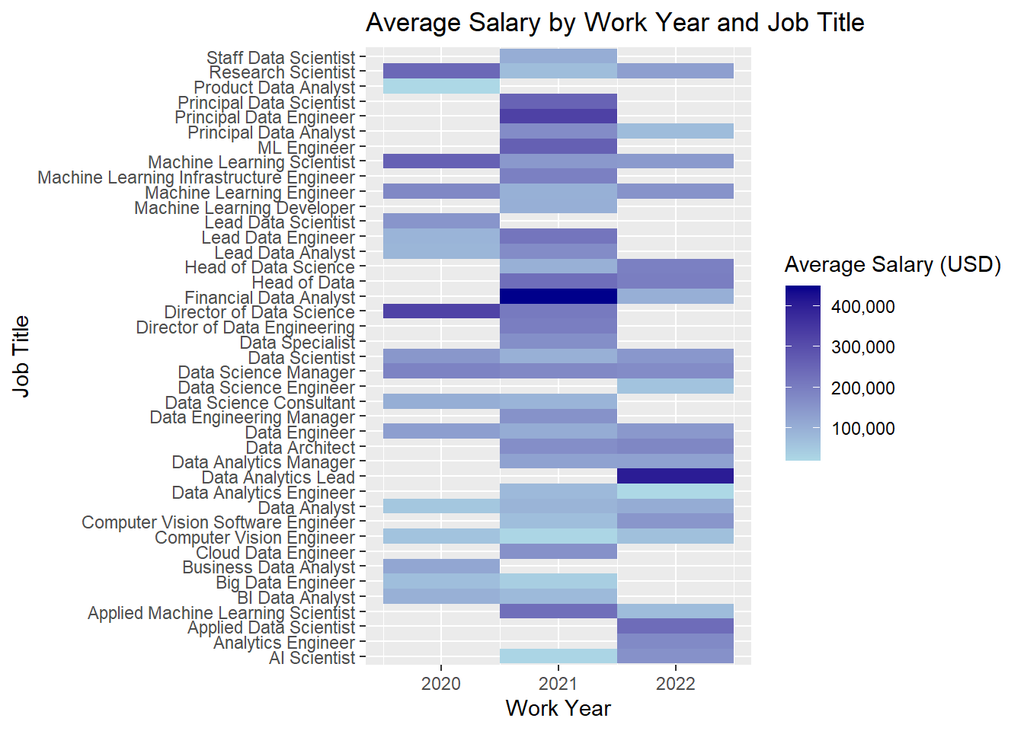

```r
# Create a heat map
ggplot(average_salary, aes(x = work_year, y = job_title, fill = salary_in_usd)) +
  geom_tile() +
  scale_fill_gradient(low = "lightblue", high = "darkblue", labels = scales::comma) +  # Remove scientific notation
  labs(title = "Average Salary by Work Year and Job Title",
       x = "Work Year",
       y = "Job Title",
       fill = "Average Salary (USD)") +
  theme(legend.position = "right")  # Adjust legend position
```

The abbreviations “EN”, “EX”, “MI”, and “SE” likely represent different experience levels. Below is a typical interpretation of these abbreviations:

- EN: Entry-level
- EX: Experienced
- MI: Mid-level
- SE: Senior-level

These abbreviations are commonly used in job postings or HR contexts to describe the level of experience required or preferred for a particular role.

```r
library(ggplot2)

# Calculate average salary by experience level, job title, and company size
average_salary <- aggregate(salary_in_usd ~ experience_level + job_title + company_size, data = df_usd, FUN = mean)
print(average_salary)
```

```
##     experience_level                                job_title company_size
## 1                 MI                             AI Scientist            L
## 2                 SE                             AI Scientist            L
## 3                 MI                   Applied Data Scientist            L
## 4                 SE                   Applied Data Scientist            L
## 5                 MI       Applied Machine Learning Scientist            L
## 6                 EX                          BI Data Analyst            L
## 7                 EN                        Big Data Engineer            L
## 8                 EN                    Business Data Analyst            L
## 9                 MI                    Business Data Analyst            L
## 10                EN                             Data Analyst            L
## 11                MI                             Data Analyst            L
## 12                SE                             Data Analyst            L
## 13                MI                  Data Analytics Engineer            L
## 14                SE                      Data Analytics Lead            L
```

[output cut: 217 more lines]

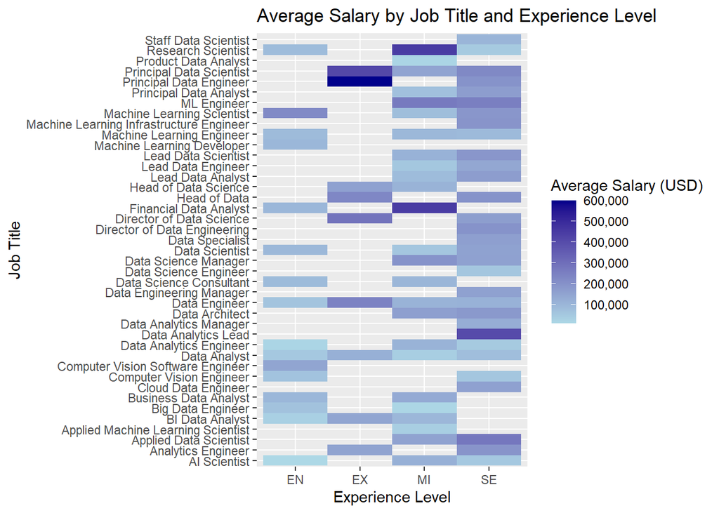

```r
# Create a heatmap
ggplot(average_salary, aes(x = experience_level, y = job_title, fill = salary_in_usd)) +
  geom_tile() +
  scale_fill_gradient(low = "lightblue", high = "darkblue", labels = scales::comma) +  # Remove scientific notation
  labs(title = "Average Salary by Job Title and Experience Level",
       x = "Experience Level",
       y = "Job Title",
       fill = "Average Salary (USD)") +
  theme(legend.position = "right")  # Adjust legend position
```

The abbreviations “L”, “M”, “S” represent different company sizes. Below is a typical interpretation of these abbreviations:

- L: Large-Sized
- M: Mid-Sized
- S: small-sized

```r
library(ggplot2)

# Calculate average salary by company size, job title, and experience level
average_salary <- aggregate(salary_in_usd ~ company_size + job_title + experience_level, data = df_usd, FUN = mean)
print(average_salary)
```

```
##     company_size                                job_title experience_level
## 1              M                             AI Scientist               EN
## 2              S                             AI Scientist               EN
## 3              S                          BI Data Analyst               EN
## 4              L                        Big Data Engineer               EN
## 5              L                    Business Data Analyst               EN
## 6              M                 Computer Vision Engineer               EN
## 7              M        Computer Vision Software Engineer               EN
## 8              S        Computer Vision Software Engineer               EN
## 9              L                             Data Analyst               EN
## 10             M                             Data Analyst               EN
## 11             S                             Data Analyst               EN
## 12             M                  Data Analytics Engineer               EN
## 13             L                            Data Engineer               EN
## 14             M                            Data Engineer               EN
```

[output cut: 217 more lines]

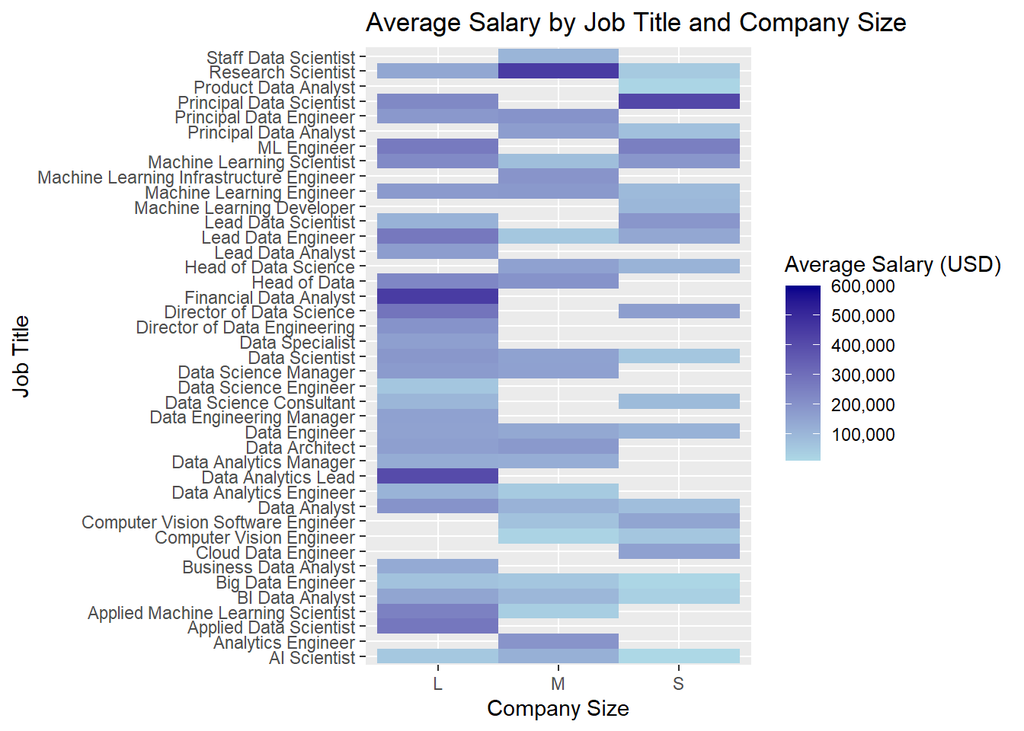

```r
# Create a heatmap
ggplot(average_salary, aes(x = company_size, y = job_title, fill = salary_in_usd)) +
  geom_tile() +
  scale_fill_gradient(low = "lightblue", high = "darkblue", labels = scales::comma) +  # Remove scientific notation
  labs(title = "Average Salary by Job Title and Company Size",
       x = "Company Size",
       y = "Job Title",
       fill = "Average Salary (USD)") +
  theme(legend.position = "right")  # Adjust legend position
```

The abbreviations “CT”, “FL”, “FT”, and “PT” likely represent different types of employment. Here’s a typical interpretation of these abbreviations:

- CT: Contract or Contractor
- FL: Freelance or Freelancer
- FT: Full-time
- PT: Part-time

These abbreviations are commonly used in employment contexts to describe the nature of the work arrangement or employment status. Each abbreviation corresponds to a different type of employment arrangement, indicating whether the position is full-time, part-time, contract-based, or freelance.

```r
library(ggplot2)

# Calculate average salary by employment type, job title, and experience level
average_salary <- aggregate(salary_in_usd ~ employment_type + job_title + experience_level, data = df_usd, FUN = mean)
print(average_salary)
```

```
##    employment_type                                job_title experience_level
## 1               PT                             AI Scientist               EN
## 2               FT                          BI Data Analyst               EN
## 3               FT                        Big Data Engineer               EN
## 4               CT                    Business Data Analyst               EN
## 5               FT                 Computer Vision Engineer               EN
## 6               FT        Computer Vision Software Engineer               EN
## 7               FT                             Data Analyst               EN
## 8               FT                  Data Analytics Engineer               EN
## 9               FT                            Data Engineer               EN
## 10              FT                  Data Science Consultant               EN
## 11              FT                           Data Scientist               EN
## 12              PT                           Data Scientist               EN
## 13              FT                   Financial Data Analyst               EN
## 14              FT               Machine Learning Developer               EN
```

[output cut: 159 more lines]

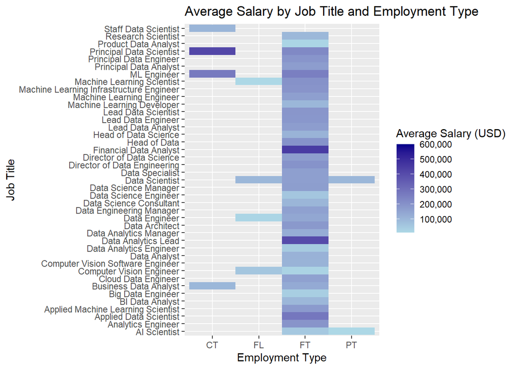

```r
# Create a heatmap
ggplot(average_salary, aes(x = employment_type, y = job_title, fill = salary_in_usd)) +
  geom_tile() +
  scale_fill_gradient(low = "lightblue", high = "darkblue", labels = scales::comma) +  # Remove scientific notation
  labs(title = "Average Salary by Job Title and Employment Type",
       x = "Employment Type",
       y = "Job Title",
       fill = "Average Salary (USD)") +
  theme(legend.position = "right")  # Adjust legend position
```

### Top 10 Data Science Job Titles by Average Salary

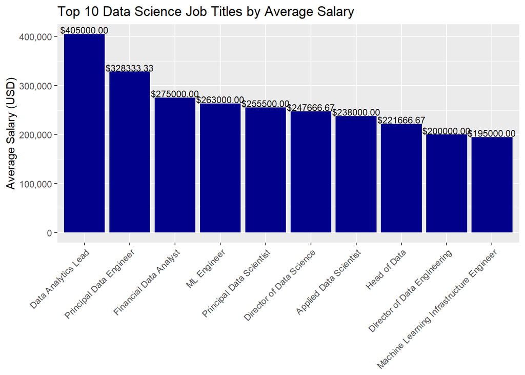

```r
library(dplyr)
library(ggplot2)

# Calculate average salary by job title
average_salary <- df_usd %>%
  group_by(job_title) %>%
  summarise(average_salary = mean(salary_in_usd)) %>%
  arrange(desc(average_salary)) %>%
  slice(1:10)  # Select top 10 job titles

# Create a bar plot
ggplot(average_salary, aes(x = reorder(job_title, -average_salary), y = average_salary)) +
  geom_bar(stat = "identity", fill = "darkblue") +
  geom_text(aes(label = sprintf("$%.2f", average_salary)), vjust = -0.1, size = 3) +  # Add salary labels
  labs(title = "Top 10 Data Science Job Titles by Average Salary",
       x = "Job Title",
       y = "Average Salary (USD)") +
  scale_y_continuous(labels = scales::comma_format()) +  # Remove scientific notation
  theme(axis.text.x = element_text(angle = 45, hjust = 1),
        axis.title.x = element_blank())  # Remove x-axis label for better readability
```